# Twitter Disaster Classification Analysis

## Display the results

```python
# Add this function after your metric display functions
def plot_training_history(history, model_name):
    """Plot training history with loss, accuracy, and F1-score"""
    fig, axes = plt.subplots(2, 2, figsize=(15, 12))
    fig.suptitle('Training History: %s' % model_name, fontsize=16)

    # Loss
    axes[0, 0].plot(history['loss'], label='Training Loss')
    axes[0, 0].plot(history['val_loss'], label='Validation Loss')
    axes[0, 0].set_title('Loss')
    axes[0, 0].set_xlabel('Epoch')
    axes[0, 0].set_ylabel('Loss')
    axes[0, 0].legend()
    axes[0, 0].grid(True, alpha=.3)

    # Accuracy
    axes[0, 1].plot(history['accuracy'], label='Training Accuracy')
    axes[0, 1].plot(history['val_accuracy'], label='Validation Accuracy')
    axes[0, 1].set_title('Accuracy')
    axes[0, 1].set_xlabel('Epoch')
    axes[0, 1].set_ylabel('Accuracy')
    axes[0, 1].legend()
    axes[0, 1].grid(True, alpha=.3)

    # F1-score (validation only)
    if 'val_f1' in history.columns:
        axes[1, 0].plot(history['val_f1'], label='Validation F1-score', color='green')
        axes[1, 0].set_title('Validation F1-score')
        axes[1, 0].set_xlabel('Epoch')
        axes[1, 0].set_ylabel('F1-score')
        axes[1, 0].legend()
        axes[1, 0].grid(True, alpha=.3)

        # Mark best F1 epoch
        best_f1_epoch = history['val_f1'].idxmax()
        best_f1_value = history['val_f1'].max()
        axes[1, 0].axvline(x=best_f1_epoch, color='red', linestyle='--', alpha=.7)
        axes[1, 0].text(best_f1_epoch + 0.5, best_f1_value - 0.05,
                       f'Best: {best_f1_value:.3f}', color='red')

    # Learning rate (if available)
    axes[1, 1].remove()  # Remove empty subplot

    plt.tight_layout()
    plt.show()

# Add this function to compare multiple models
def compare_training_histories(models, title=""):
    """Compare training histories of multiple models"""
    fig, axes = plt.subplots(2, 2, figsize=(15, 12))
    fig.suptitle(f'Model Comparison: %s' % title, fontsize=16)

    colors = plt.cm.Set3(np.linspace(0, 1, len(models)))

    for i, (model_name, history) in enumerate(models):
        color = colors[i]

        # Loss
        axes[0, 0].plot(history['val_loss'], label=model_name, color=color, alpha=.8)

        # Accuracy
        axes[0, 1].plot(history['val_accuracy'], label=model_name, color=color, alpha=.8)

        # F1-score
        axes[1, 0].plot(history['val_f1'], label=model_name, color=color, alpha=.8)

    # Format loss subplot
    axes[0, 0].set_title('Validation Loss')
    axes[0, 0].set_xlabel('Epoch')
    axes[0, 0].set_ylabel('Loss')
    axes[0, 0].legend()
    axes[0, 0].grid(True, alpha=.3)

    # Format accuracy subplot
    axes[0, 1].set_title('Validation Accuracy')
    axes[0, 1].set_xlabel('Epoch')
    axes[0, 1].set_ylabel('Accuracy')
    axes[0, 1].legend()
    axes[0, 1].grid(True, alpha=.3)

    # Format F1 subplot
    axes[1, 0].set_title('Validation F1-score')
    axes[1, 0].set_xlabel('Epoch')
    axes[1, 0].set_ylabel('F1-score')
    axes[1, 0].legend()
    axes[1, 0].grid(True, alpha=.3)

    # Remove empty subplot
    axes[1, 1].remove()

    plt.tight_layout()
    plt.show()
```

```
Model: LSTM, layers=1, units=48, dropout=0.0
    F1-score: 0.829    Accuracy: 0.856    Precision: 0.848    Recall: 0.810
```

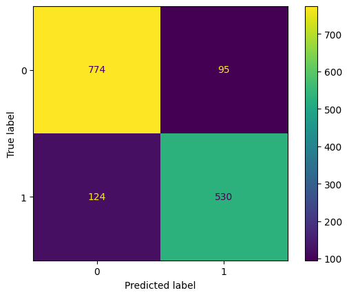

```
Model: LSTM, layers=3, units=48, dropout=0.4
    F1-score: 0.815    Accuracy: 0.844    Precision: 0.834    Recall: 0.797
Model: LSTM, layers=1, units=48, dropout=0.2
    F1-score: 0.810    Accuracy: 0.834    Precision: 0.797    Recall: 0.823
Model: LSTM, layers=2, units=48, dropout=0.4
    F1-score: 0.808    Accuracy: 0.840    Precision: 0.835    Recall: 0.783
Model: LSTM, layers=2, units=48, dropout=0.0
    F1-score: 0.808    Accuracy: 0.838    Precision: 0.827    Recall: 0.789
Model: LSTM, layers=1, units=64, dropout=0.4
    F1-score: 0.797    Accuracy: 0.831    Precision: 0.824    Recall: 0.772
Model: LSTM, layers=2, units=48, dropout=0.2
    F1-score: 0.791    Accuracy: 0.825    Precision: 0.810    Recall: 0.774
Model: LSTM, layers=3, units=48, dropout=0.0
    F1-score: 0.791    Accuracy: 0.820    Precision: 0.790    Recall: 0.792
Model: LSTM, layers=3, units=48, dropout=0.2
    F1-score: 0.790    Accuracy: 0.829    Precision: 0.836    Recall: 0.749
Model: LSTM, layers=3, units=64, dropout=0.4
    F1-score: 0.789    Accuracy: 0.825    Precision: 0.820    Recall: 0.760
Model: LSTM, layers=1, units=64, dropout=0.0
    F1-score: 0.783    Accuracy: 0.822    Precision: 0.823    Recall: 0.746
Model: LSTM, layers=1, units=48, dropout=0.4
    F1-score: 0.779    Accuracy: 0.814    Precision: 0.797    Recall: 0.761
Model: LSTM, layers=3, units=64, dropout=0.0
    F1-score: 0.777    Accuracy: 0.812    Precision: 0.791    Recall: 0.763
Model: LSTM, layers=1, units=64, dropout=0.2
    F1-score: 0.776    Accuracy: 0.810    Precision: 0.783    Recall: 0.769
Model: LSTM, layers=2, units=64, dropout=0.0
    F1-score: 0.776    Accuracy: 0.820    Precision: 0.835    Recall: 0.725
Model: LSTM, layers=2, units=64, dropout=0.4
    F1-score: 0.771    Accuracy: 0.794    Precision: 0.738    Recall: 0.807
Model: LSTM, layers=2, units=64, dropout=0.2
    F1-score: 0.767    Accuracy: 0.797    Precision: 0.756    Recall: 0.780
Model: LSTM, layers=3, units=64, dropout=0.2
    F1-score: 0.759    Accuracy: 0.798    Precision: 0.777    Recall: 0.742
```

```python
# Display the LSTM models in descending order based on their F1 scores
# Also show the confusion matrix of the top model
lstm_models = [model for model in rnn_models if model["params"]["rnn_layer"] == layers.LSTM]
lstm_models.sort(key=lambda model: model["metrics"]["f1"], reverse=True)
for i, model in enumerate(lstm_models):
    display_model_metrics(model["name"], **model["metrics"], show_cm=i==0)
```

```
Model: GRU, layers=3, units=64, dropout=0.2
    F1-score: 0.857    Accuracy: 0.882    Precision: 0.892    Recall: 0.824
```

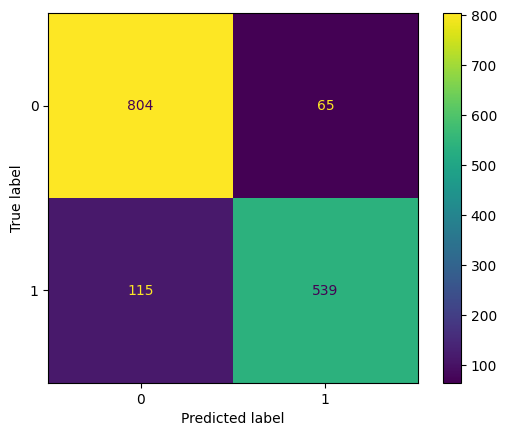

```
Model: GRU, layers=1, units=48, dropout=0.0
    F1-score: 0.821    Accuracy: 0.850    Precision: 0.844    Recall: 0.800
Model: GRU, layers=2, units=64, dropout=0.0
    F1-score: 0.818    Accuracy: 0.846    Precision: 0.832    Recall: 0.804
Model: GRU, layers=1, units=64, dropout=0.2
    F1-score: 0.813    Accuracy: 0.848    Precision: 0.859    Recall: 0.772
Model: GRU, layers=1, units=64, dropout=0.0
    F1-score: 0.811    Accuracy: 0.840    Precision: 0.827    Recall: 0.795
Model: GRU, layers=3, units=48, dropout=0.2
    F1-score: 0.807    Accuracy: 0.840    Precision: 0.839    Recall: 0.778
Model: GRU, layers=1, units=48, dropout=0.2
    F1-score: 0.804    Accuracy: 0.834    Precision: 0.814    Recall: 0.795
Model: GRU, layers=2, units=48, dropout=0.2
    F1-score: 0.792    Accuracy: 0.821    Precision: 0.788    Recall: 0.797
Model: GRU, layers=3, units=64, dropout=0.0
    F1-score: 0.787    Accuracy: 0.823    Precision: 0.812    Recall: 0.765
Model: GRU, layers=3, units=48, dropout=0.4
    F1-score: 0.786    Accuracy: 0.823    Precision: 0.815    Recall: 0.760
Model: GRU, layers=1, units=64, dropout=0.4
    F1-score: 0.779    Accuracy: 0.814    Precision: 0.793    Recall: 0.766
Model: GRU, layers=2, units=48, dropout=0.0
    F1-score: 0.777    Accuracy: 0.812    Precision: 0.789    Recall: 0.766
Model: GRU, layers=3, units=64, dropout=0.4
    F1-score: 0.774    Accuracy: 0.800    Precision: 0.754    Recall: 0.795
Model: GRU, layers=3, units=48, dropout=0.0
    F1-score: 0.773    Accuracy: 0.810    Precision: 0.792    Recall: 0.755
Model: GRU, layers=2, units=48, dropout=0.4
    F1-score: 0.768    Accuracy: 0.798    Precision: 0.757    Recall: 0.780
Model: GRU, layers=1, units=48, dropout=0.4
    F1-score: 0.766    Accuracy: 0.806    Precision: 0.792    Recall: 0.742
Model: GRU, layers=2, units=64, dropout=0.4
    F1-score: 0.761    Accuracy: 0.791    Precision: 0.749    Recall: 0.772
Model: GRU, layers=2, units=64, dropout=0.2
    F1-score: 0.759    Accuracy: 0.792    Precision: 0.756    Recall: 0.761
```

```python
# Display the GRU models in descending order based on their F1 scores
# Also show the confusion matrix of the top model
gru_models = [model for model in rnn_models if model["params"]["rnn_layer"] == layers.GRU]
gru_models.sort(key=lambda model: model["metrics"]["f1"], reverse=True)
for i, model in enumerate(gru_models):
    display_model_metrics(model["name"], **model["metrics"], show_cm=i==0)
```

```
Training History for Top LSTM Model:
```

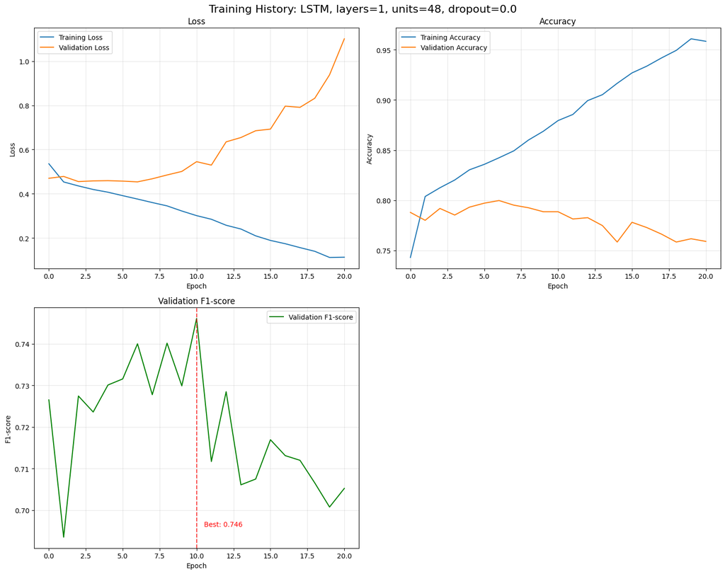

```python
# Plot training history for top LSTM model
print("Training History for Top LSTM Model:")
plot_training_history(lstm_models[0]["history"], lstm_models[0]["name"])
```

```
Training History for Top GRU Model:
```

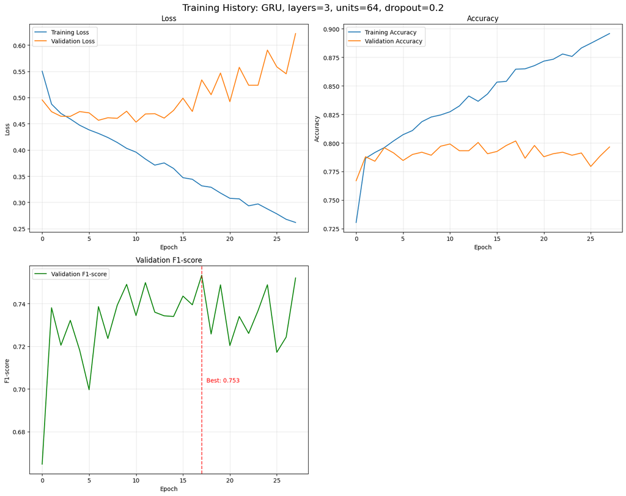

```python
# Plot training history for top GRU model
print("Training History for Top GRU Model:")
plot_training_history(gru_models[0]["history"], gru_models[0]["name"])
```

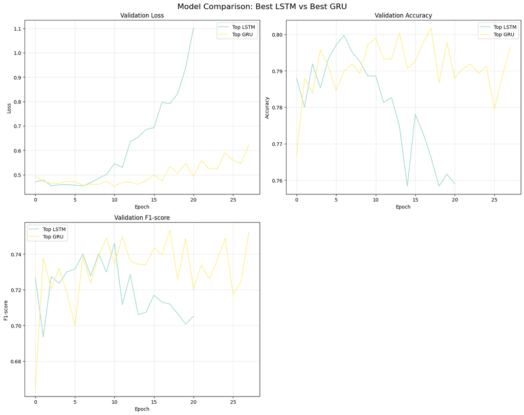

```python
# Compare top models from each category
top_models = [
    ('Top LSTM', lstm_models[0]["history"]),
    ('Top GRU', gru_models[0]["history"])
]
compare_training_histories(top_models, "Best LSTM vs Best GRU")
```

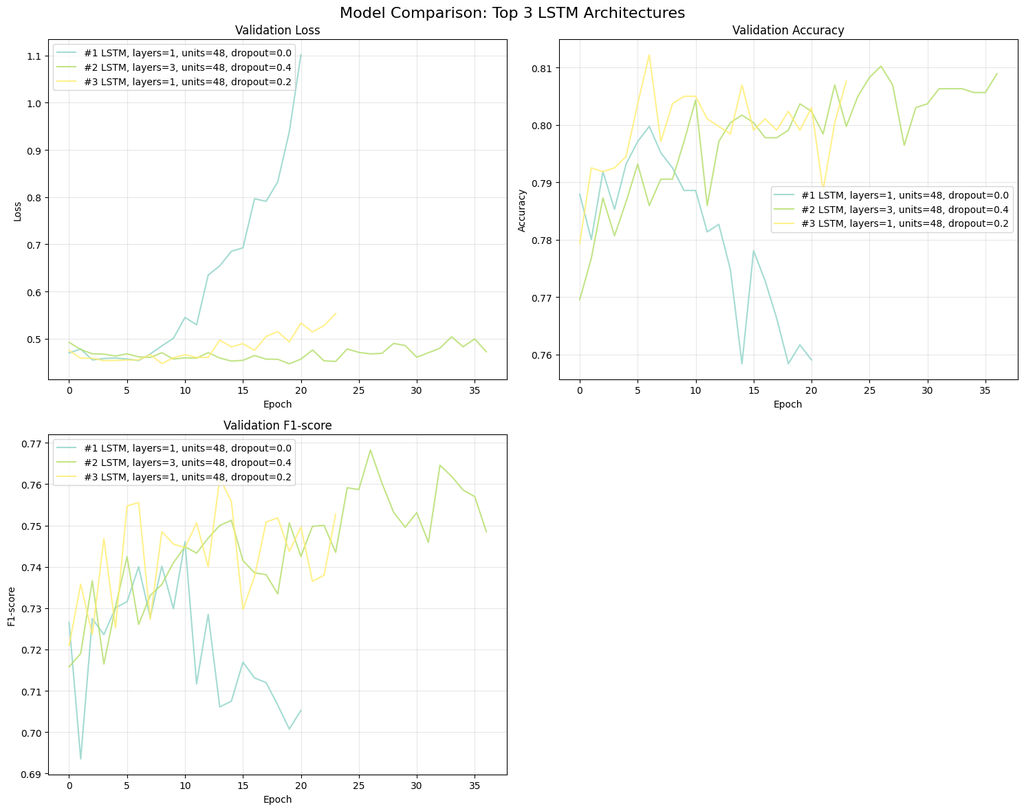

```python
# Compare different architectures within LSTM
lstm_comparison = []
for i, model in enumerate(lstm_models[:3]):  # Top 3 LSTM models
    lstm_comparison.append(("#%d %s" % (i+1, model["name"]), model["history"]))
compare_training_histories(lstm_comparison, "Top 3 LSTM Architectures")
```

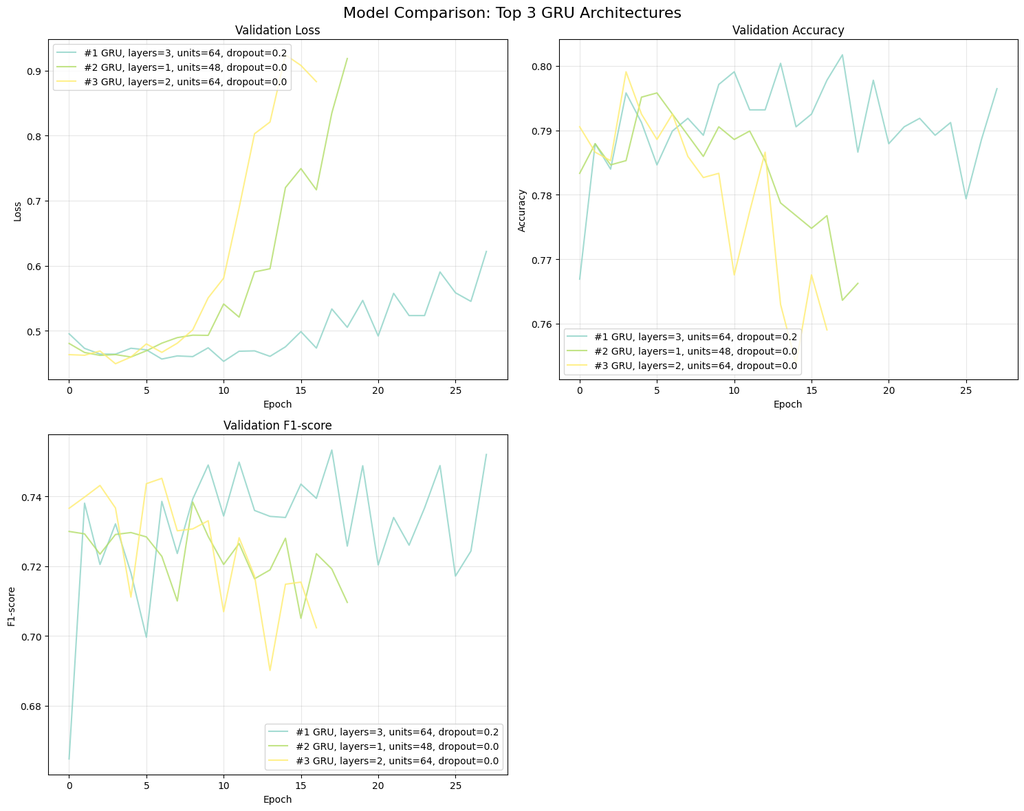

```python
# Compare different architectures within GRU
gru_comparison = []
for i, model in enumerate(gru_models[:3]):  # Top 3 GRU models
    gru_comparison.append(("#%d %s" % (i+1, model["name"]), model["history"]))
compare_training_histories(gru_comparison, "Top 3 GRU Architectures")
```

## Model Comparison and Selection based on F1-score

```
Model Performance Comparison (Sorted by F1-score):
               accuracy        f1 precision    recall
GRU            0.881812  0.856916  0.892384  0.824159
LSTM           0.856205  0.828772     0.848  0.810398
Random Forest   0.67761  0.617303  0.629571  0.605505

Best Model: GRU
Best F1-score: 0.857
```

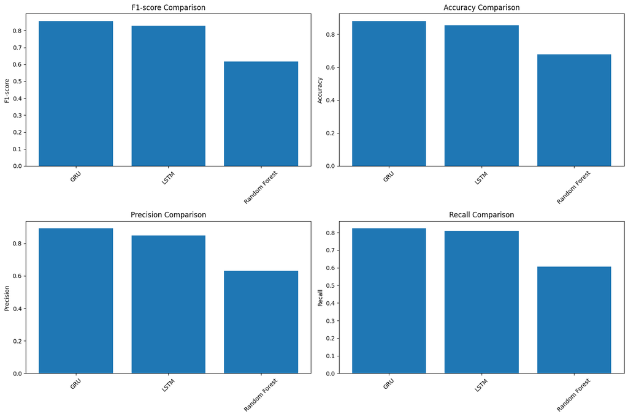

```python
# Store all model results for comparison
model_results = {
    'Random Forest': rf_metrics,
    'LSTM': lstm_models[0]["metrics"],
    'GRU': gru_models[0]["metrics"],
}

# Create comparison DataFrame
comparison_df = pd.DataFrame(model_results)[:4].T
comparison_df = comparison_df.sort_values('f1', ascending=False)

print("Model Performance Comparison (Sorted by F1-score):")
print(comparison_df)

# Select best model based on F1-score
best_model_name = comparison_df.index[0]
best_model_metrics = comparison_df.iloc[0]

print("\nBest Model:", best_model_name)
print("Best F1-score: %.3f" % best_model_metrics['f1'])

# Visual comparison
fig, axes = plt.subplots(2, 2, figsize=(15, 10))

# F1-score comparison
axes[0, 0].bar(comparison_df.index, comparison_df['f1'])
axes[0, 0].set_title('F1-score Comparison')
axes[0, 0].set_ylabel('F1-score')
axes[0, 0].tick_params(axis='x', rotation=45)

# Accuracy comparison
axes[0, 1].bar(comparison_df.index, comparison_df['accuracy'])
axes[0, 1].set_title('Accuracy Comparison')
axes[0, 1].set_ylabel('Accuracy')
axes[0, 1].tick_params(axis='x', rotation=45)

# Precision comparison
axes[1, 0].bar(comparison_df.index, comparison_df['precision'])
axes[1, 0].set_title('Precision Comparison')
axes[1, 0].set_ylabel('Precision')
axes[1, 0].tick_params(axis='x', rotation=45)

# Recall comparison
axes[1, 1].bar(comparison_df.index, comparison_df['recall'])
axes[1, 1].set_title('Recall Comparison')
axes[1, 1].set_ylabel('Recall')
axes[1, 1].tick_params(axis='x', rotation=45)

plt.tight_layout()
plt.show()
```

# Results Submission with Best Model

```python
# Generate predictions using the best model based on F1-score
if best_model_name == 'Random Forest':
    best_predictions = rf_classifier.predict(X_test_rf)
elif best_model_name == 'LSTM':
    best_predictions = np.round(lstm_models[0]["instance"].predict(X_test_rnn)).astype(int).flatten()
elif best_model_name == 'GRU':
    best_predictions = np.round(gru_models[0]["instance"].predict(X_test_rnn)).astype(int).flatten()

# Create submission file
submission = pd.DataFrame({
    'id': df_test['id'],
    'target': best_predictions
})

submission.to_csv('submission.csv', index=False)
print('Submission file created successfully using %s (F1-score: %.3f)' % (best_model_name, best_model_metrics["f1"]))
```

```
102/102 ━━━━━━━━━━━━━━━━━━━━ 7s 66ms/step
Submission file created successfully using GRU (F1-score: 0.857)
```

## Detailed Model Analysis

```python
print("Detailed Model Performance Analysis:")
for model_name, metrics in model_results.items():
    print("\n%s:" % model_name)
    print("  F1-score: %.3f" % metrics['f1'])
    print("  Accuracy: %.3f" % metrics['accuracy'])
    print("  Precision: %.3f" % metrics['precision'])
    print("  Recall: %.3f" % metrics['recall'])
```

```
Detailed Model Performance Analysis:

Random Forest:
  F1-score: 0.617
  Accuracy: 0.678
  Precision: 0.630
  Recall: 0.606

LSTM:
  F1-score: 0.829
  Accuracy: 0.856
  Precision: 0.848
  Recall: 0.810

GRU:
  F1-score: 0.857
  Accuracy: 0.882
  Precision: 0.892
  Recall: 0.824
```

## Discussion

It seems that for this data, LSTM and GRU achieved almost the same score, with GRU having an edge. Inspecting the training histories, it seems the fluctuations are large enough such that randomness plays a huge factor. Nevertheless, it seems that a clear pattern can be seen in that increasing the dropout is significantly reducing the overfitting of the data. This can be seen in all the metrics, especially in the validation loss and validation accuracy.

To reduce the effect of overfitting, The F1ScoreCallback class stops the training early when it detects that the validation f1 score has been falling. This is not ideal however, as the top f1 score recorded might have been due to luck rather than good fitting. By looking at the training histories, it can be seen that models without dropout are stopped rather quickly, and the higher the dropout the higher the chance of the training continuing till the end.

When it comes to the number of layers, it also seems that they are performing better, especially when combined with a high dropout. The differences are not significant enough though to rule out it being to randomness.

It must be noted that there is a huge cost associated with the dropout, which is the training time. When certain conditions are met, TensorFlow can optimize the use of the GPU to a great extent. These conditions include no dropout in the RNN layer, meaning that using dropout prevents these optimizations. Quoting the [TensorFlow documentation](https://www.tensorflow.org/api_docs/python/tf/keras/layers/GRU#used-in-the-notebooks):

> Based on available runtime hardware and constraints, this layer will choose different implementations (cuDNN-based or backend-native) to maximize the performance. If a GPU is available and all the arguments to the layer meet the requirement of the cuDNN kernel (see below for details), the layer will use a fast cuDNN implementation when using the TensorFlow backend.

> The requirements to use the cuDNN implementation are:
> 1. activation == tanh
> 2. recurrent_activation == sigmoid
> 3. dropout == 0 and recurrent_dropout == 0
> 4. unroll is False
> 5. use_bias is True
> 6. reset_after is True
> 7. Inputs, if use masking, are strictly right-padded.
> 8. Eager execution is enabled in the outermost context.

This is clearly visible during training, as models with dropout take more than 10 times the training time.

To summarize, there was a big problem with overfitting when training the RNN models. To solve that two solutions were used: Adding dropout to the RNN layers themselves, and using early-stopping. The solutions did help remedy the situation, but both are less than ideal.

The results didn't seem to be consistent with the choices of parameters, suggesting that randomness is playing a bigger factor.

Future steps:

- Try to use other methods to reduce overfitting.
- Check if even larger models can produce better results.
- **When building the model, try to use the fact that positives have a higher average text length.**

## References

1. [Disaster tweet classificator based on LSTM or GRU](https://www.kaggle.com/code/mikeliux/disaster-tweet-classificator-based-on-lstm-or-gru) by [Miguel D B](https://www.kaggle.com/mikeliux)
2. [GloVe: Global Vectors for Word Representation](https://nlp.stanford.edu/projects/glove/)
3. [glove.twitter.27B.100d.txt](https://www.kaggle.com/datasets/bertcarremans/glovetwitter27b100dtxt), a kaggle dataset copied from the above project.